### 2.4 颜色、大小、形状等图形属性

与plot()不同，qplot()可自动完成图形属性(如颜色、形状等)设置。比如向钻石重量和价格的散点图添加颜色和切工信息：

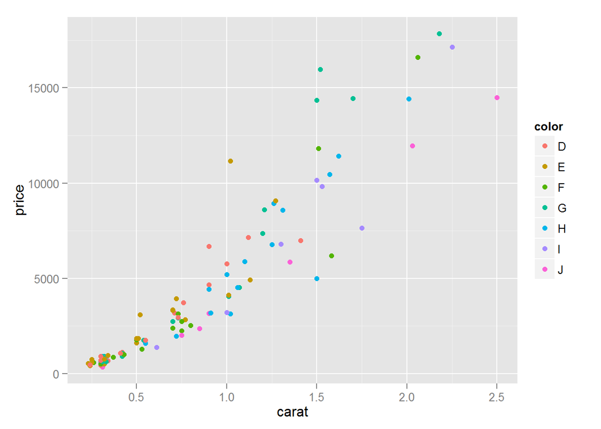

```r
qplot(carat,price,data = dsmall, colour = color) #散点图中添加颜色信息
```

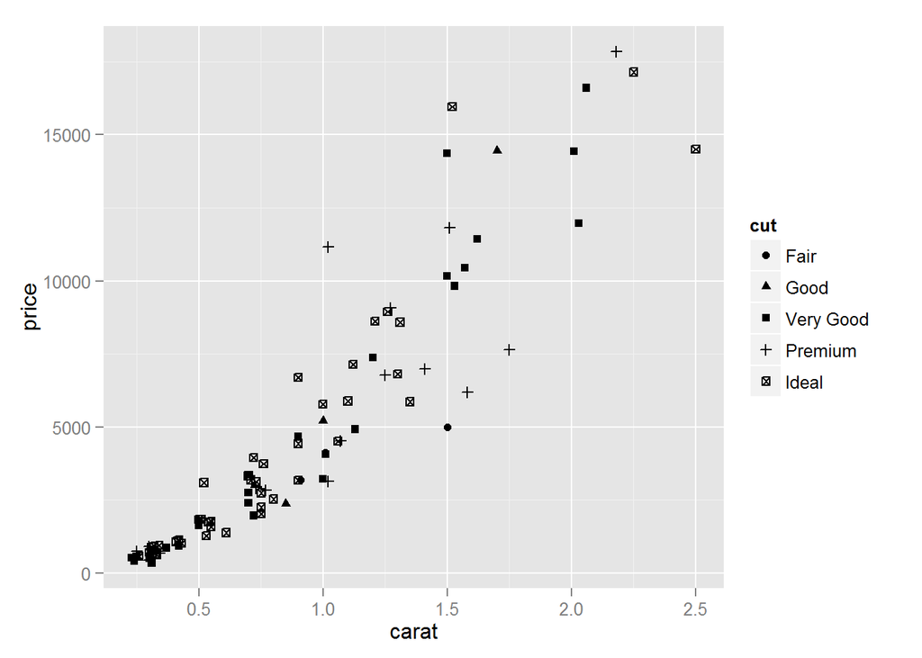

```r
qplot(carat,price,data = dsmall, shape = cut) #散点图中添加切工信息
```

颜色、大小和形状是图形属性的具体例子，是影响图形的数据属性。每一个图形属性都对应一个称为**标度**的函数，其作用是将数据的取值映射到该图形属性的有效取值。

除了由ggplot2自动设定属性外，还可利用`I()`手动设定图形属性，例如，`colour = I("red")`或`size = I(2)`。

对于大数据而言，使用半透明的颜色可以有效减轻图形元素重叠的现象。创建半透明颜色可使用`alpha`图形属性，但取值从0（完全透明）变动到1（完全不透明）。通常透明度可以用分数来进行表示，例如1/10，其分母表示经过多少次重叠后颜色将变得不透明。（*其实是不透明度*）

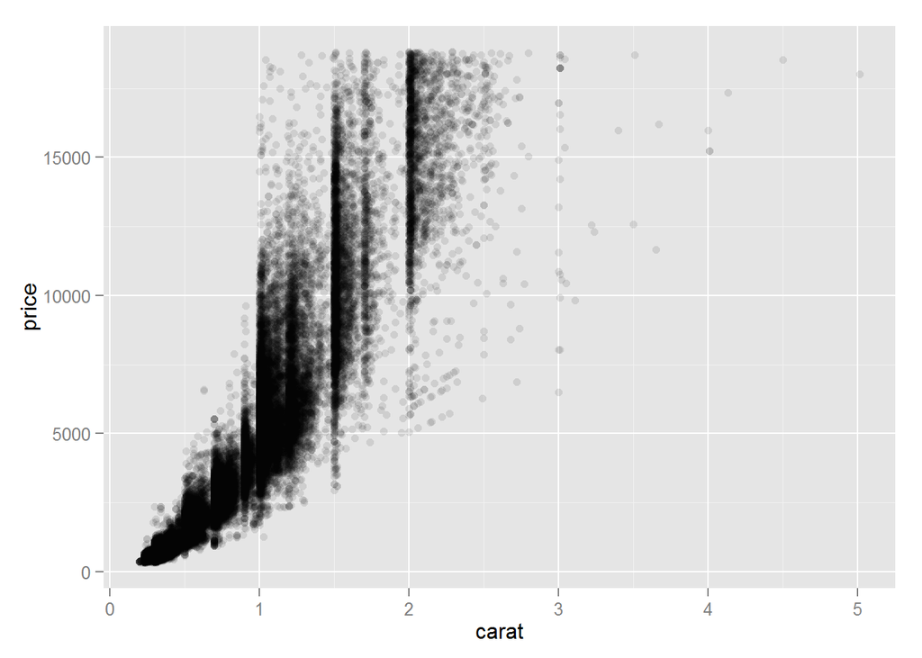

```r
qplot(carat,price,data = diamonds,alpha=I(1/10))
```

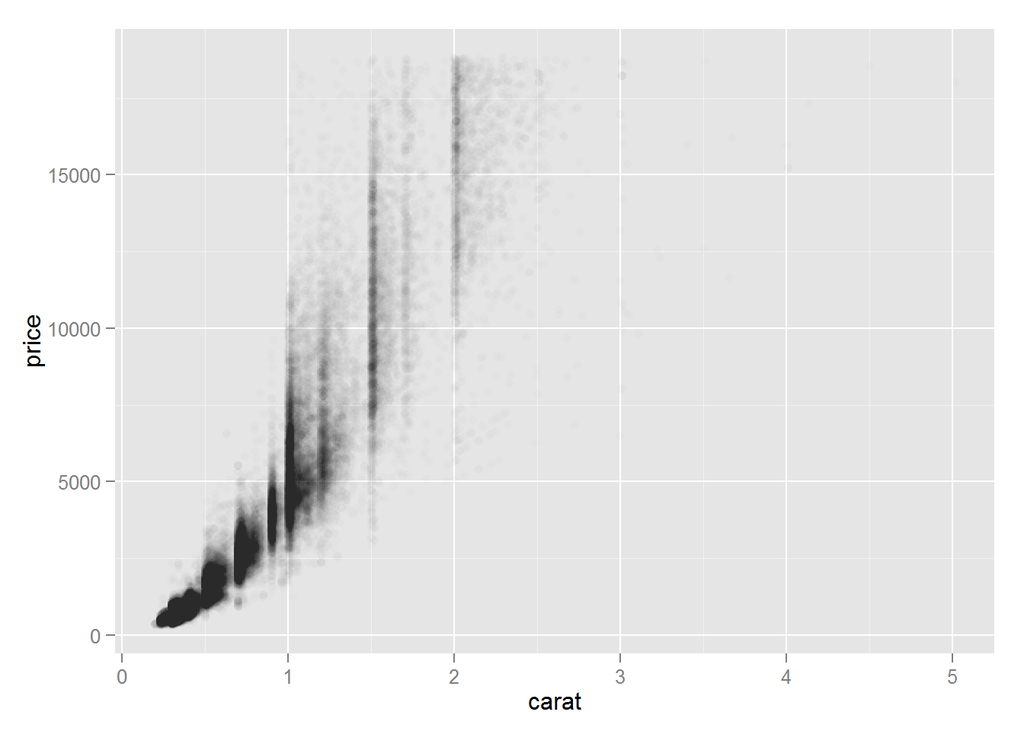

```r
qplot(carat,price,data = diamonds,alpha=I(1/100))
```

### 2.5 几何对象

qplot除了画散点图外，通过改变几何对象可以画出任何一种类型的图形。**几何对象(geom)**描述应用何种对象来对数据进行展示，其中有些几何对象关联了相应的统计变换。例如，直方图相当于分组计数再加上条形的几何对象。其中最常用的几种几何对象(二维变量关系)如下：

- `geom = "point"`绘制散点图，指定x和y后，qplot()默认画散点图；
- `geom = "smooth"`拟合一条平滑曲线，并将曲线和标准误展示在图中；
- `geom = "boxplot"`绘制箱线胡须图；
- `geom = "path" 和 geom = "line"`可以在数据点间绘制连线；

而对于一维的分布，几何对象的选择是由变量的类型指定的：

- 对于连续变量，`geom = "histogram"`绘制直方图，`geom = "freqpoly"`绘制频率多边形，`geom = "density"`绘制密度曲线。若只有x参数传递给qplot()，那么默认绘制直方图。
- 对于离散变量，`geom = "bar"`绘制条形图。

#### 2.5.1 添加平滑曲线

可使用`c()`函数将多个几何对象组成一个向量传递给`geom`:

```
## geom_smooth: method="auto" and size of largest group is <1000, so using loess. Use 'method = x' to change the smoothing method.
```

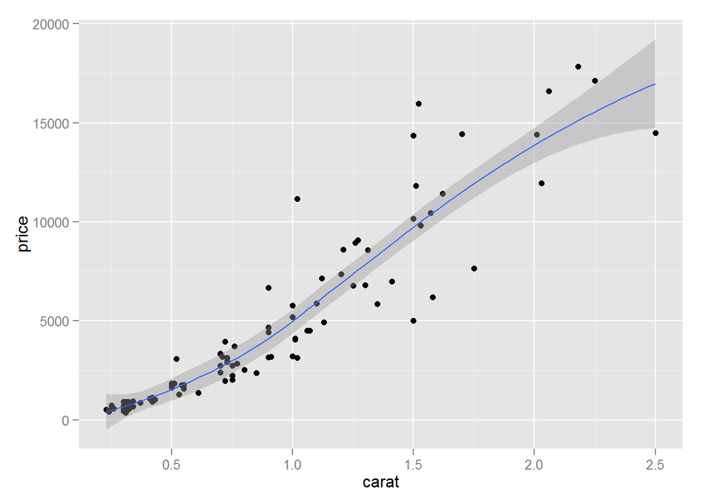

```r
qplot(carat,price,data = dsmall, geom = c("point","smooth"))
```

```
## geom_smooth: method="auto" and size of largest group is >=1000, so using gam with formula: y ~ s(x, bs = "cs"). Use 'method = x' to change the smoothing method.
```

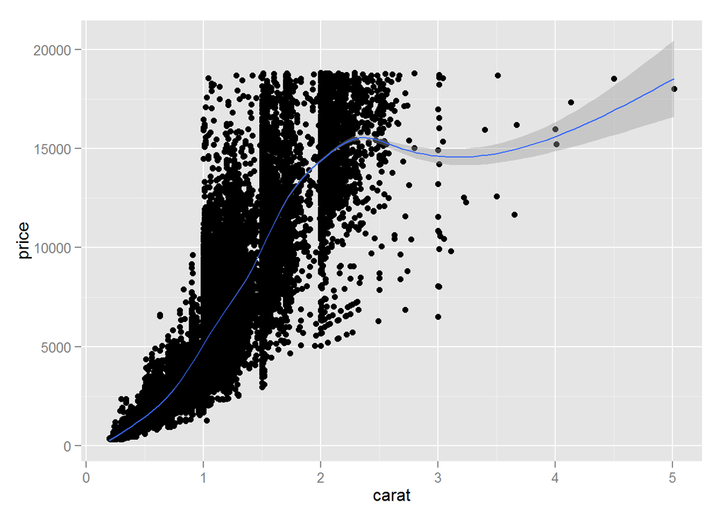

```r
qplot(carat,price,data = diamonds, geom = c("point","smooth"))
```

其中，灰色部分表示逐点置信区间。如不绘制标准误，可使用参数`se = FALSE`。此外，利用`method`参数可选择多种平滑器：

- `method = "loess"`,当n较小时是默认选项，使用局部回归。曲线的平滑程度由`span`参数控制，其取值范围从0（很不平滑）到1（很平滑），如：

```
## geom_smooth: method="auto" and size of largest group is <1000, so using loess. Use 'method = x' to change the smoothing method.
```

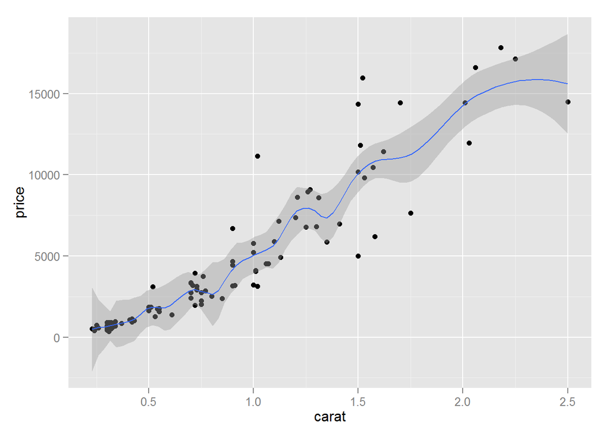

```r
qplot(carat,price,data = dsmall,geom = c("point","smooth"),span = 0.2)
```

```
## geom_smooth: method="auto" and size of largest group is <1000, so using loess. Use 'method = x' to change the smoothing method.
```

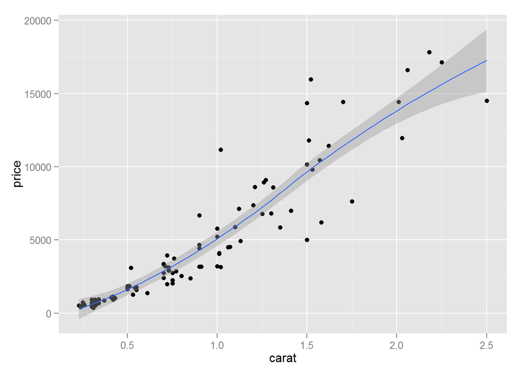

```r
qplot(carat,price,data = dsmall,geom = c("point","smooth"),span = 1.0)
```

loess对大数据并不适用，其内存消耗为$O(n^2)$.

- 当$n>1000$时，可使用`method = "gam", formula = y ~ s(x)`调用`mgcv`包拟合一个广义可加模型。这与函数`lm`使用样条类似。对于大数据，使用公式$y ~ s(x, bs = "cs")$，这是数据量超过1000时的默认选项。

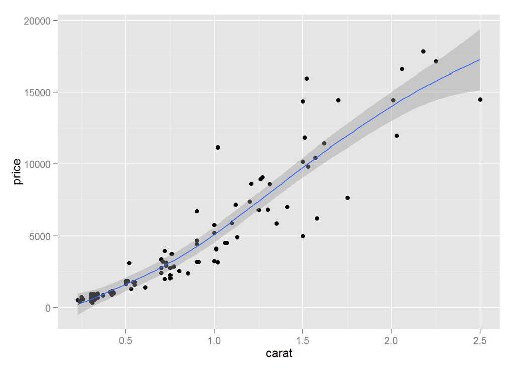

```r
library("mgcv")
qplot(carat,price,data = dsmall,geom = c("point","smooth"),method = "gam", formula = y ~ s(x))
```

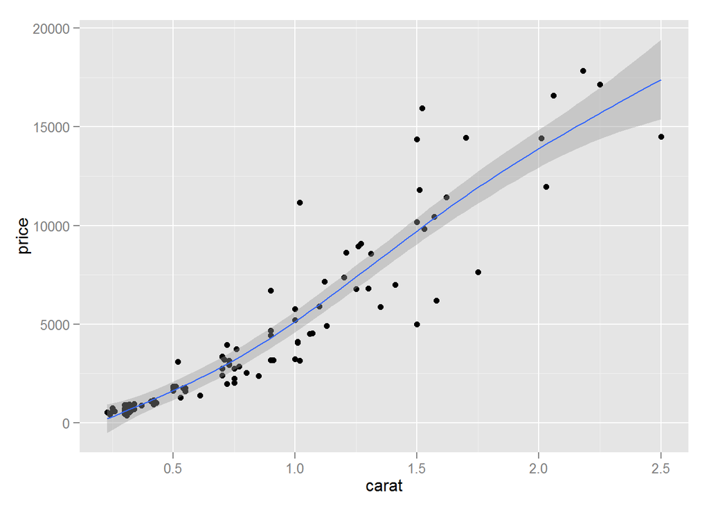

```r
qplot(carat,price,data = dsmall,geom = c("point","smooth"),method = "gam", formula = y ~ s(x,bs="cs"))
```

- `method = "lm"`拟合的是线性模型，默认拟合一条直线。通过指定`formula = y ~ poly(x,2)`来拟合二次多项式或加载`splines`包以使用自然样条：`formula = y ~ ns(x,2)`，其中第二个参数是自由度，其取值越大，曲线的波动就越大。

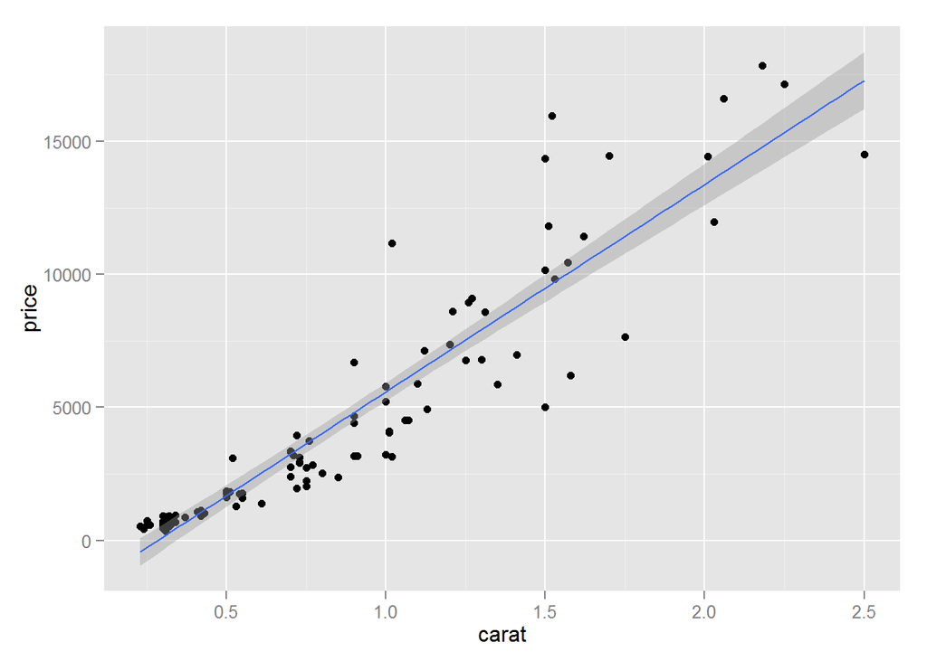

```r
library("splines")
qplot(carat,price,data = dsmall,geom = c("point","smooth"),method = "lm")
```

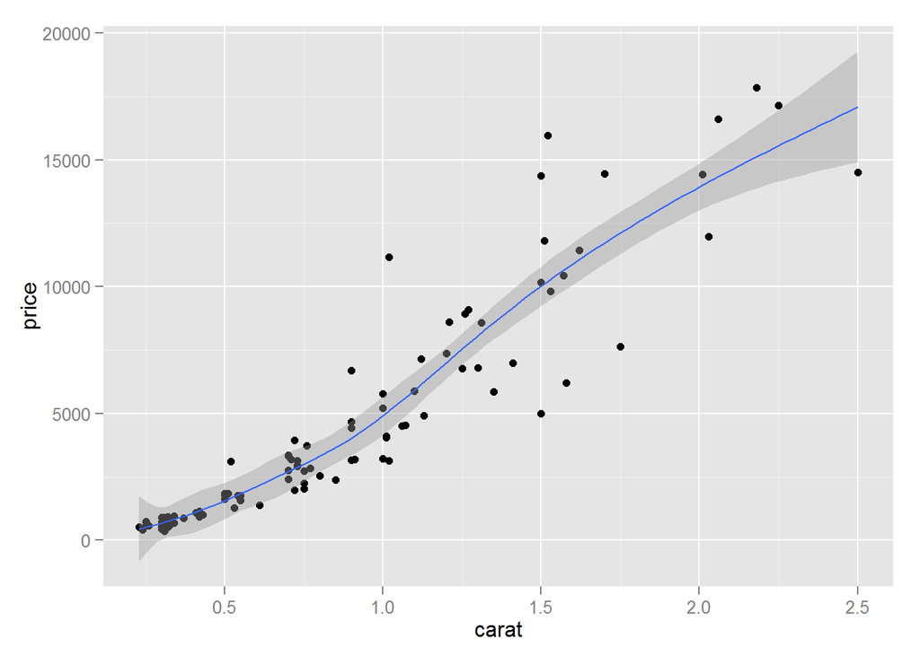

```r
qplot(carat,price,data = dsmall,geom = c("point","smooth"),method = "lm",formula = y ~ ns(x,5))
```

- `method = "rlm"`与lm类似，但采用更稳健的拟合算法，使得结果对异常值不太敏感。该方法依赖`MASS`包：

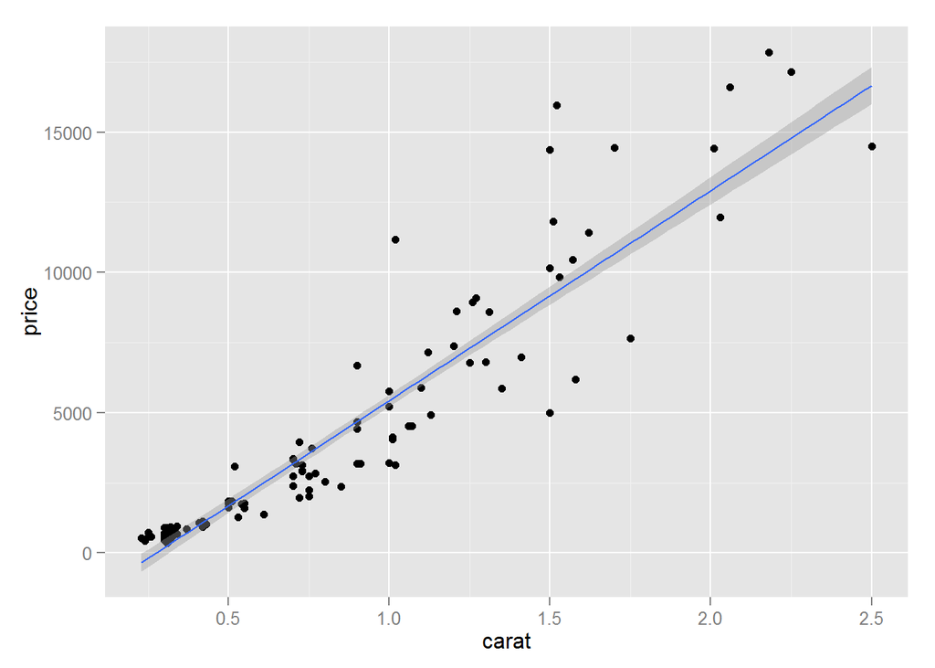

```r
library("MASS")
qplot(carat,price,data = dsmall, geom = c("point","smooth"), method = "rlm")
```

#### 2.5.2 箱线图和扰动点图

如果数据集中包含分类变量和连续变量，那么连续变量可能随分类变量而变化，此时可用箱线图和扰动点图